# Supplementary material 3

Testing interaction assembly in Ecuadorian plant–frugivore networks

## 1 Ecological question

Can regional interaction structure help explain the nestedness and modularity of six observed local plant–frugivore networks in Ecuador? The records come from the [archived case study](https://zenodo.org/records/5537283). The included data contain observed interactions at six sites. We combine all recorded species pairs into one regional network, also called a metaweb, and fit one stochastic block model (SBM) to it. The SBM groups species by their interaction patterns and estimates an interaction probability for each pair of groups.

This supplement includes the records, the fitted regional model, and results from 49 simulated networks for each scenario at each site. The document loads the fitted model and simulation results when it renders; the fitting and simulation code is shown for readers but is not run. Only one small local network is reconstructed to illustrate MetaWeave. The sites span 1,000, 2,000 and 3,000 m elevation, with two networks at each level. Elevation orders the comparison; it is not an input to the regional SBM. The question is whether its interaction probabilities and the species present locally lead to different structural predictions along this gradient.

We compare three ensembles at each site. Every simulated network has the observed number of distinct links.

| Ensemble | Species | Link allocation |
| --- | --- | --- |
| A: neutral | Observed local species | Equal chance among possible pairs |
| B: regional SBM | Observed local species | Weighted by regional SBM probabilities |
| C: changed composition | Random species from the regional pools, matched to local plant and frugivore richness | Weighted by the same regional SBM |

**B − A** changes the interaction rule while holding composition fixed. **B − C** changes composition while holding the regional interaction rule fixed. These are differences in network metrics, not z scores. Random regional species are sampled with equal probability, an explicit simplifying assumption about arrival and establishment.

## 2 Load the regional model and reconstruct a site

We fit one SBM to the interactions pooled across all six sites. The model assigns each plant and frugivore to a group and estimates a probability of interaction for each combination of plant and frugivore groups. These assignments and probabilities are included with the supplement and form the regional input to MetaWeave. We use this same model at every site.

In the first chunk, `block_model()` turns those saved assignments and probabilities into one regional interaction rule. `new_assemblage()` lists the plants and frugivores recorded at a site, and `infer_network()` applies the rule to that assemblage. The returned matrix contains one interaction probability for each locally possible species pair.

```r
# Apply the pooled regional SBM to a locally recorded assemblage.
library(metaweave)
library(tidyverse)

source_data <- new.env()
load("data/ecuador/dataSet1.RData", envir = source_data)
records <- source_data$dataSet1$N
records <- records |>
  filter(frequency > 0) |>
  mutate(across(c(site, plantCode, animalCode), as.character))

regional <- readRDS("data/ecuador/pooled_sbm_fit.rds")
regional_rule <- block_model(
  regional$row_lookup, regional$column_lookup, regional$theta,
  "plants", "animals"
)

sites <- sort(unique(records$site))
first_site <- records |> filter(site == sites[1])
local_plants <- sort(unique(first_site$plantCode))
local_animals <- sort(unique(first_site$animalCode))
community <- new_assemblage(
  list(plants = local_plants, animals = local_animals), cell_id = 1L
)
local_probabilities <- infer_network(community, regional_rule)$matrix
tibble(site = sites[1], plants = nrow(local_probabilities),
       frugivores = ncol(local_probabilities),
       expected_links = round(sum(local_probabilities), 1))
```

```
# A tibble: 1 × 4
  site       plants frugivores expected_links
  <chr>       <int>      <int>          <dbl>
1 Bellavista     21         15           19.4
```

Each entry of `local_probabilities` is the regional model’s probability for a pair whose species occur at this site. MetaWeave supplies this local matrix. The next step uses its values as weights in a fixed-link-count simulation; they are not independent Bernoulli draws.

### 2.1 How the regional fit was obtained

To fit the regional model, we first combine the records from all six sites into a single binary network. Its entries represent observed species pairs: a pair is marked present if recorded at least once. The following displayed code shows the essential fitting and translation steps. It is not rerun in this document; `cassandRa` is required only when fitting a new regional model.

```r
# Make one binary metaweb from all sites, ignoring repeat frequency.
plant_pool <- sort(unique(records$plantCode))
animal_pool <- sort(unique(records$animalCode))
metaweb <- matrix(0L, length(plant_pool), length(animal_pool),
                  dimnames = list(plant_pool, animal_pool))
metaweb[cbind(match(records$plantCode, plant_pool),
              match(records$animalCode, animal_pool))] <- 1L

# Fit once regionally; do not refit the model at individual sites.
set.seed(5537283)
candidate_fits <- cassandRa::FitSBM(
  list = cassandRa::CreateListObject(metaweb), n_SBM = 10, G = NULL
)
best <- candidate_fits$SBM1
theta <- best$Omega_rs
rownames(theta) <- paste0("plant_block_", seq_len(nrow(theta)))
colnames(theta) <- paste0("animal_block_", seq_len(ncol(theta)))
row_lookup <- tibble(species = plant_pool,
                     guild = rownames(theta)[as.integer(best$SB_H)])
column_lookup <- tibble(species = animal_pool,
                        guild = colnames(theta)[as.integer(best$SB_W)])
```

The regional network contains 102 plants, 127 frugivores and 536 recorded species pairs. The selected SBM has ten plant groups and ten frugivore groups. The following table shows the estimated probabilities between those groups, which `block_model()` uses to build local predictions.

```r
# Display the regional network size and fitted interaction probabilities.
tibble(plants = nrow(regional$metaweb),
       frugivores = ncol(regional$metaweb),
       regional_links = sum(regional$metaweb),
       plant_blocks = nrow(regional$theta),
       frugivore_blocks = ncol(regional$theta))
```

```
# A tibble: 1 × 5
  plants frugivores regional_links plant_blocks frugivore_blocks
   <int>      <int>          <int>        <int>            <int>
1    102        127            536           10               10
```

```r
as_tibble(regional$theta, rownames = "plant_block")
```

```
# A tibble: 10 × 11
   plant_block    animal_block_1 animal_block_2 animal_block_3 animal_block_4
   <chr>                   <dbl>          <dbl>          <dbl>          <dbl>
 1 plant_block_1          0.025          0.075           0              0
 2 plant_block_2          0              0.0139          0.264          0.190
 3 plant_block_3          0              0               0.625          0.375
 4 plant_block_4          0              0               0.362          0
 5 plant_block_5          0              0.0139          0              0
 6 plant_block_6          0              0               0.142          0
 7 plant_block_7          0.0208         0.177           0              0
 8 plant_block_8          0              0               0              0
 9 plant_block_9          0.125          0               0.625          0
10 plant_block_10         0.271          0               0              0
# ℹ 6 more variables: animal_block_5 <dbl>, animal_block_6 <dbl>,
#   animal_block_7 <dbl>, animal_block_8 <dbl>, animal_block_9 <dbl>,
#   animal_block_10 <dbl>
```

## 3 Generate the comparison

The following code constructs the three sets of simulated networks. For each site, it starts with the recorded species and links, then draws networks under each of the three rules described above. The regional model is fitted once to the pooled network; it is not refitted for each draw.

```r
# Generate the three ensembles using the pooled regional model.
  library(vegan)
  library(bipartite)

  local_matrix <- function(x) {
    plants <- sort(unique(x$plantCode))
    animals <- sort(unique(x$animalCode))
    m <- matrix(0L, length(plants), length(animals),
                dimnames = list(plants, animals))
    m[cbind(match(x$plantCode, plants),
            match(x$animalCode, animals))] <- 1L
    m
  }

  probabilities <- function(plants, animals, id) {
    assemblage <- new_assemblage(
      list(plants = plants, animals = animals), cell_id = id
    )
    infer_network(assemblage, regional_rule)$matrix
  }


  fixed_links <- function(p, n, weighted) {
    positions <- sample.int(length(p), n, replace = FALSE,
                            prob = if (weighted) as.vector(p) else NULL)
    m <- matrix(0L, nrow(p), ncol(p))
    m[positions] <- 1L
    m
  }


  network_metrics <- function(m) {
    c(nodf = as.numeric(vegan::nestednodf(m)$statistic[["NODF"]]),
      modularity = as.numeric(bipartite::computeModules(m)@likelihood))
  }
```

Within each draw, `new_assemblage()` supplies either the observed species or a richness-matched selection from the regional pool to `infer_network()`. MetaWeave reconstructs the local probability matrix under the *same* regional `block_model()` each time. The subsequent link sampling and NODF and modularity calculations use base R, `vegan` and `bipartite`; they follow MetaWeave’s prediction. The document shows the code and loads its saved output for the tables and figure.

```r
  repetitions <- 49L
  set.seed(5537283)
  plant_pool <- sort(unique(records$plantCode))
  animal_pool <- sort(unique(records$animalCode))
  scenarios <- c("A_observed_neutral", "B_observed_sbm", "C_random_sbm")
  draws <- array(NA_real_, c(length(sites), repetitions, 3L, 2L),
                 dimnames = list(sites, NULL, scenarios,
                                 c("nodf", "modularity")))
  observed <- matrix(NA_real_, length(sites), 2L,
                     dimnames = list(sites, c("nodf", "modularity")))
  site_info <- data.frame(site = sites, elevation = NA_real_,
                          plants = NA_integer_, animals = NA_integer_,
                          links = NA_integer_)

  for (i in seq_along(sites)) {
    x <- records[records$site == sites[i], ]
    m <- local_matrix(x)
    n_links <- sum(m)
    site_info$elevation[i] <- unique(x$elevation)
    site_info$plants[i] <- nrow(m)
    site_info$animals[i] <- ncol(m)
    site_info$links[i] <- n_links
    observed[i, ] <- network_metrics(m)
    p_local <- probabilities(rownames(m), colnames(m), i)

    for (r in seq_len(repetitions)) {
      random_plants <- sort(sample(plant_pool, nrow(m)))
      random_animals <- sort(sample(animal_pool, ncol(m)))
      p_random <- probabilities(random_plants, random_animals, i)
      draws[i, r, "A_observed_neutral", ] <-
        network_metrics(fixed_links(p_local, n_links, FALSE))
      draws[i, r, "B_observed_sbm", ] <-
        network_metrics(fixed_links(p_local, n_links, TRUE))
      draws[i, r, "C_random_sbm", ] <-
        network_metrics(fixed_links(p_random, n_links, TRUE))
    }
  }
  analysis <- list(site_info = site_info, observed = observed,
                   draws = draws, reps = repetitions, seed = 5537283L)
```

### 3.1 Sites along the gradient

The number of plants, frugivores and distinct links varies among sites. Every ensemble retains its site’s plant richness, frugivore richness and link count, so the contrasts below do not arise simply from drawing networks of different sizes.

The following table lists the elevation, recorded species richness and number of distinct links at each site. These describe the observed networks used to set the size of each simulation.

```r
# Describe the observed assemblages in elevation order.
site_table <- analysis$site_info |>
  as_tibble() |>
  arrange(elevation, site) |>
  select(site, elevation, plants, frugivores = animals, links)
site_table
```

```
# A tibble: 6 × 5
  site       elevation plants frugivores links
  <chr>          <dbl>  <int>      <int> <int>
1 Bombuscaro      1000     24         50   182
2 Copalinga       1000     21         74   210
3 ECSF            2000     17         34    66
4 Finca           2000     20         38    82
5 Bellavista      3000     21         15    36
6 Cajanuma        3000     16         13    32
```

## 4 Read the contrasts

Nestedness (binary NODF) is higher when specialists’ links tend to be subsets of generalists’ links. Modularity is higher when interactions are more concentrated within groups. For each site we compare B with A and C draw by draw, then show the mean difference and its central 95% simulation interval. A circle in the figure represents **B − A**, the effect of using regional interaction weights for the observed species; a triangle represents **B − C**, the effect of keeping the observed species instead of a richness-matched regional draw. Neither symbol is an observed network metric.

The contrast chunk subtracts metrics calculated after sampling links from MetaWeave’s local probability matrices. It pairs draws within a site and reports the mean and central interval of each metric difference. The subtraction is in NODF or modularity units, not a standardized score.

```r
# Calculate interaction-rule and composition contrasts within each site.
contrast <- function(metric, reference) {
  b <- analysis$draws[, , "B_observed_sbm", metric]
  other <- analysis$draws[, , reference, metric]
  difference <- b - other
  tibble(
    site = dimnames(analysis$draws)[[1]],
    metric = metric,
    contrast = paste("B -", substr(reference, 1, 1)),
    mean = rowMeans(difference),
    lower = apply(difference, 1, quantile, 0.025),
    upper = apply(difference, 1, quantile, 0.975)
  )
}

comparison <- bind_rows(
  contrast("nodf", "A_observed_neutral"),
  contrast("nodf", "C_random_sbm"),
  contrast("modularity", "A_observed_neutral"),
  contrast("modularity", "C_random_sbm")
  ) |>
  left_join(as_tibble(analysis$site_info) |>
              select(site, elevation), by = "site")
comparison |>
  arrange(elevation, site, metric, contrast)
```

```
# A tibble: 24 × 7
   site       metric     contrast    mean    lower    upper elevation
   <chr>      <chr>      <chr>      <dbl>    <dbl>    <dbl>     <dbl>
 1 Bombuscaro modularity B - A    -0.0479  -0.0747 -0.0243       1000
 2 Bombuscaro modularity B - C    -0.124   -0.180  -0.0358       1000
 3 Bombuscaro nodf       B - A    13.0      9.27   17.5          1000
 4 Bombuscaro nodf       B - C    -1.57   -13.4    11.2          1000
 5 Copalinga  modularity B - A    -0.0491  -0.0785 -0.0240       1000
 6 Copalinga  modularity B - C    -0.124   -0.196  -0.0446       1000
 7 Copalinga  nodf       B - A    15.9     11.3    20.0          1000
 8 Copalinga  nodf       B - C    -0.512  -10.5    13.8          1000
 9 ECSF       modularity B - A    -0.0615  -0.117   0.00340      2000
10 ECSF       modularity B - C    -0.0430  -0.143   0.0564       2000
# ℹ 14 more rows
```

The contrasts describe differences among simulated ensembles. The observed networks provide another reference: for example, a site may be more nested than all three ensemble means even when B − A is positive. The following table keeps observed structure and the three simulated means side by side. These means summarize 49 realizations, not 49 field networks.

Here A, B and C summarize networks sampled after MetaWeave’s `infer_network()` step. The `observed` column comes from field records; MetaWeave does not estimate that column.

```r
# Place observed metrics beside each ensemble's mean prediction.
ensemble_table <- map_dfr(c("nodf", "modularity"), function(metric) {
  tibble(
    site = analysis$site_info$site,
    elevation_m = analysis$site_info$elevation,
    metric = metric,
    observed = analysis$observed[, metric],
    A_neutral = rowMeans(analysis$draws[, , "A_observed_neutral", metric]),
    B_regional_SBM = rowMeans(analysis$draws[, , "B_observed_sbm", metric]),
    C_changed_species = rowMeans(analysis$draws[, , "C_random_sbm", metric])
  )
})
ensemble_table |>
  mutate(across(c(observed, A_neutral, B_regional_SBM,
                  C_changed_species), ~ round(.x, 2))) |>
  arrange(elevation_m, site, metric)
```

```
# A tibble: 12 × 7
   site       elevation_m metric     observed[,1]  [,2] A_neutral B_regional_SBM
   <chr>            <dbl> <chr>             <dbl> <dbl>     <dbl>          <dbl>
 1 Bombuscaro        1000 modularity         0.31  0.31      0.38           0.33
 2 Bombuscaro        1000 nodf              41.1  41.1      16.2           29.2
 3 Copalinga         1000 modularity         0.33  0.33      0.4            0.35
 4 Copalinga         1000 nodf              58.4  58.4      14.1           30.0
 5 ECSF              2000 modularity         0.5   0.5       0.52           0.46
 6 ECSF              2000 nodf              32.2  32.2      11.3           15.9
 7 Finca             2000 modularity         0.49  0.49      0.52           0.47
 8 Finca             2000 nodf              34.8  34.8      10.7           14.9
 9 Bellavista        3000 modularity         0.63  0.63      0.57           0.63
10 Bellavista        3000 nodf              13.1  13.1      10.4            9.41
11 Cajanuma          3000 modularity         0.57  0.57      0.52           0.5
12 Cajanuma          3000 nodf              23.1  23.1      15.1           13.4
# ℹ 2 more variables: observed[3:6] <dbl>, C_changed_species <dbl>
```

The figure plots the contrasts derived above, ordering the sites by the elevation supplied with their observed records. It visualizes the consequences of applying MetaWeave’s regional rule to different local assemblages and link-allocation scenarios; elevation itself is not a predictor in `block_model()` or `infer_network()`.

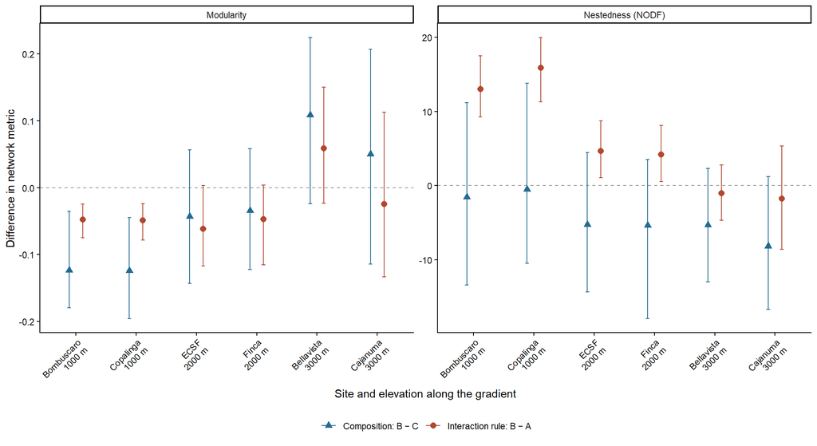

Network assembly contrasts along the Ecuador elevation gradient. Sites are ordered from 1,000 to 3,000 m, with two sites per elevation. Circles show B − A (regional interaction rule); triangles show B − C (species composition). Points are means and vertical bars are central 95% intervals across 49 paired draws. The dashed line is zero difference.

```r
# Keep site labels and both contrasts aligned along the elevation gradient.
site_labels <- site_table |>
  mutate(label = paste0(site, "\n", elevation, " m"))
plot_data <- comparison |>
  left_join(site_labels |> select(site, label), by = "site") |>
  mutate(label = factor(label, levels = site_labels$label),
         metric = recode(metric, nodf = "Nestedness (NODF)",
                         modularity = "Modularity"),
         contrast = recode(contrast, `B - A` = "Interaction rule: B − A",
                           `B - C` = "Composition: B − C"))

ggplot(plot_data, aes(x = label, y = mean, colour = contrast,
                      shape = contrast, group = contrast)) +
  geom_hline(yintercept = 0, linetype = 2, colour = "grey60") +
  geom_errorbar(aes(ymin = lower, ymax = upper), width = 0.12,
                position = position_dodge(width = 0.45)) +
  geom_point(size = 2.4, position = position_dodge(width = 0.45)) +
  facet_wrap(~ metric, scales = "free_y", nrow = 1) +
  scale_colour_manual(values = c("Interaction rule: B − A" = "#B2472F",
                                 "Composition: B − C" = "#246B91")) +
  scale_shape_manual(values = c("Interaction rule: B − A" = 16,
                                "Composition: B − C" = 17)) +
  labs(x = "Site and elevation along the gradient",
       y = "Difference in network metric", colour = NULL, shape = NULL) +
  theme_classic() +
  theme(axis.text.x = element_text(angle = 45, hjust = 1),
        legend.position = "bottom")
```

At the two 1,000-m sites, regional interaction weighting increased nestedness by about 13 and 16 NODF units relative to uniform allocation, and reduced modularity by about 0.05. The nestedness difference was smaller at 2,000 m and its interval crossed zero at both 3,000-m sites. The B − C nestedness intervals crossed zero at all six sites. This is a pattern across these six networks, not a fitted elevation effect or a test of a general altitudinal trend.

An interval crossing zero means these 49 simulations do not clearly separate the two scenarios for that metric and site. The intervals describe variation among simulated networks, not uncertainty across Ecuadorian sites. The observed network is a separate reference; the contrasts isolate modeling choices rather than proving that any process caused its structure. The regional-pool randomization does not model unequal dispersal, habitat filtering, or species’ abundance.